# regression_nis

# 1 Preliminaries

The purpose of this script is to set up a master dataset with which to filter a particular patient population based on ICD-10 codes and then set up input variables for linear/logistic regression.

Set working directory. Load packages. Replace “data” with local name for data directory.

```r
data_dir <- "data"

library(Hmisc)
library(mice)
library(knitr)
library(GGally)
library(naniar)
library(here)
library(patchwork)
library(tableone)
library(caret)
library(iNZightRegression)
library(survey)
library(yarrr)
library(gtsummary)
library(tidyverse)
```

# 2 Data Management

## 2.1 Load Data

```r
regression_data <- readRDS(here(data_dir, "regression_data_smm_nonimputed.rds"))
```

## 2.2 Clean data types

Code demographic variables and other info for input into linear regression models. We’re going to use a variety of predictors to predict total cost (`totchg`) of the hospital stay for patients diagnosed with severe maternal mortality, accounting for a weighted survey design using the `discwt` variable.

Below, we’ll use `mutate` and `case_when` to create new factor variables.

```r
regression_data_smm <- regression_data %>%
  mutate(key_nis = as.character(key_nis),
         age_cat = factor(case_when(age < 18 ~ "0-17",
                                    age >= 18 & age < 30 ~ "18-29",
                                    age >= 30 & age < 45 ~ "30-44",
                                    age >= 45 & age < 60 ~ "45-59",
                                    age >= 60 ~ "60+"), ordered = TRUE),
         race_cat = factor(case_when(race == 1 ~ "a_white", # forcing a to be first, so white will be reference
                                     race == 2 ~ "b_black",
                                     race == 3 ~ "c_hispanic",
                                     race == 4 ~ "d_asian/pacific island",
                                     race == 5 ~ "e_native american",
                                     race == 6 ~ "f_other")),
         aprdrg_risk_mortality = factor(aprdrg_risk_mortality, ordered = TRUE), # can't be factor for lm below
         aprdrg_risk_mortality = factor(case_when(aprdrg_risk_mortality == 0 |
                                             aprdrg_risk_mortality == 1 ~ "0-1",
                                           aprdrg_risk_mortality == 2 ~ "2",
                                           aprdrg_risk_mortality == 3 ~ "3",
                                           aprdrg_risk_mortality == 4 ~ "4"), ordered = TRUE),
         aprdrg_severity = factor(case_when(aprdrg_severity == 0 |
                                              aprdrg_severity == 1 ~ "0-1",
                                            aprdrg_severity == 2 ~ "2",
                                            aprdrg_severity == 3 ~ "3",
                                            aprdrg_severity == 4 ~ "4"), ordered = TRUE),
         aprdrg_severity = factor(aprdrg_severity, ordered = TRUE), # should be factor though,
                                                                      # we'll probably update the model
                                                                      # choice if we go with this
         payer_cat = factor(case_when(pay1 == 1 ~ "c_medicare", # forcing a to be first, so private will be ref
                                      pay1 == 2 ~ "d_medicaid",
                                      pay1 == 3 ~ "a_private",
                                      pay1 == 4 ~ "b_self",
                                      pay1 == 5 ~ "e_no charge",
                                      pay1 == 6 ~ "f_other")),
         h_contrl_cat = factor(case_when(h_contrl == 1 ~ "b_govt", # private, non profit is reference
                                         h_contrl == 2 ~ "a_pvt_non_prof",
                                         h_contrl == 3 ~ "c_pvt_for_prof")),
         zipinc_qrtl = factor(zipinc_qrtl, ordered = TRUE), # convert to ordinal
         los_cat = factor(case_when(los >= 0 & los <= 1 ~ "0-1",
                             los == 2 ~ "2",
                             los == 3 ~ "3",
                             los >= 4 & los <= 5 ~ "4-5",
                             los >= 6 & los <= 8 ~ "6-8",
                             los >= 9 & los <= 12 ~ "9-12",
                             los >= 13 & los <= 20 ~ "13-20",
                             los >= 21 ~ "21+"), ordered = TRUE,
                          levels = c("0-1", "2", "3", "4-5", "6-8", "9-12", "13-20", "21+"))) %>%
  mutate_at(vars(matches("cmr_")), factor) %>%
  select(-c(age, race, pay1, h_contrl, los)) # remove original variables when we altered their categories
```

## 2.3 Missingness

### 2.3.1 Assess missing values

Below, we use `gg_miss_var` to visualize how many samples are missing for each of the variables in our dataset. As promised, the `race` variable has the greatest number of missing values, according to the two plots below. After that, `zipinc_qrtl`, `totchg`, `pl_nchs`, `elective`, `payer_cat`, `amonth`, and `age_cat` have a few missing values each.

Next, the second plot, produced using `gg_miss_upset` allows us to see how many samples have missing values for each combination of the variables. Most samples are only missing one variable, and just a few samples are missing multiple. We’ll go forward with imputation.

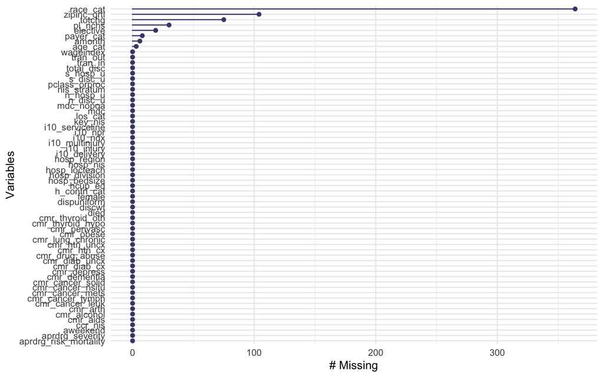

```r
gg_miss_var(regression_data_smm)
```

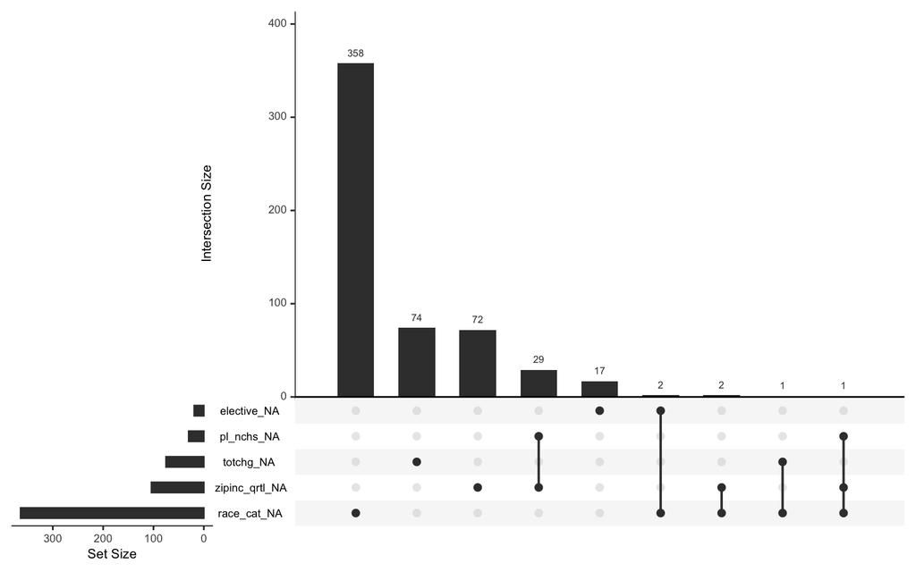

```r
gg_miss_upset(regression_data_smm)
```

Because `totchg` is our outcome variable, we will not impute those data. Let’s filter our `regression_data_smm` for complete cases in this variable before moving forward with imputation.

```r
regression_data_smm <- regression_data_smm %>%
  filter(complete.cases(totchg))
```

### 2.3.2 Impute `race_cat`, `zipinc_qrtl`, `pl_nchs`, `elective`, `payer_cat`, `amonth`, and `age_cat`

Because the data are likely not Missing Completely at Random (MCAR), removing all samples with `NA` values may cause our model to be biased. We will move forward with imputation using the `mice` package.

This code is based on the tutorial [here](https://www.r-bloggers.com/2016/06/handling-missing-data-with-mice-package-a-simple-approach/).

```r
init <- mice(regression_data_smm, maxit=0)
meth = init$method
predM = init$predictorMatrix

# remove variables we think will be less useful (to cut down on imputation time)
cmr_codes <- colnames(regression_data_smm)[grep("cmr_", colnames(regression_data_smm))]
keep_var <- c("i10_ndx", "los_cat", "pclass_orproc", "pl_nchs", "totchg",
              "elective", "zipinc_qrtl", "aprdrg_risk_mortality",
              "aprdrg_severity", "age_cat", "race_cat", "payer_cat",
              "h_contrl_cat", cmr_codes)
remove_var <- colnames(regression_data_smm)[!(colnames(regression_data_smm) %in% keep_var)]

predM[, remove_var] = 0

# specify methods for imputing missing values
# "polyreg" for unordered categorical
# "polr" for ordered categorical
# based on cran documentation for `mice` function in `mice` package:
# https://search.r-project.org/CRAN/refmans/mice/html/mice.html
meth[c("race_cat")]="polyreg"
meth[c("pl_nchs")]="polyreg"
meth[c("payer_cat")]="polyreg"
meth[c("amonth")]="polyreg"

meth[c("elective")]="logreg"

meth[c("zipinc_qrtl")]="polr"
meth[c("age_cat")]="polr"

# run imputation
# this should take ~ 20 minutes

# uncomment to re-run imputation
# set.seed(0)
# imputed = mice(regression_data_smm, method=meth, predictorMatrix=predM, m=5)
# regression_data_smm_imputed <- complete(imputed)
# saveRDS(regression_data_smm_imputed, here(data_dir, "regression_data_smm_imputed.rds"))

# uncomment to read in results
regression_data_smm_imputed <- readRDS(here(data_dir, "regression_data_smm_imputed.rds"))
```

## 2.4 Describe data

We’ll use the `describe` function in the `Hmisc` package to take a quick look at all of our variables here. We’ll make sure that each variable is encoded with the appropriate datatype and assess if any of them should be removed.

Some of the `cmr` variables are very infrequent. It may be best to not include those predictors which occur in less than 1% of the samples. This will reduce the chance that differences in training/testing sets will influence model performance.

```r
data_describe <- Hmisc::describe(regression_data_smm_imputed)

html(data_describe)
```

regression_data_smm_imputed  
63 Variables 12149 Observations

amonth

| n | missing | distinct |
| --- | --- | --- |
| 12149 | 0 | 12 |

lowest : 1 2 3 4 5 , highest: 8 9 10 11 12

```
 Value          1     2     3     4     5     6     7     8     9    10    11    12
 Frequency   1020   923   973   909  1023   932  1106  1079  1071  1089   974  1050
 Proportion 0.084 0.076 0.080 0.075 0.084 0.077 0.091 0.089 0.088 0.090 0.080 0.086
```

aweekend

| n | missing | distinct |
| --- | --- | --- |
| 12149 | 0 | 2 |

```
 Value          0     1
 Frequency   9926  2223
 Proportion 0.817 0.183
```

died

| n | missing | distinct |
| --- | --- | --- |
| 12149 | 0 | 2 |

```
 Value          0     1
 Frequency  12115    34
 Proportion 0.997 0.003
```

discwt

| n | missing | distinct | Info | Mean | Gmd | .05 | .10 | .25 | .50 | .75 | .90 | .95 |
| --- | --- | --- | --- | --- | --- | --- | --- | --- | --- | --- | --- | --- |
| 12149 | 0 | 146 | 0.98 | 5 | 5.154e-05 | 5 | 5 | 5 | 5 | 5 | 5 | 5 |

lowest : 4.996870 4.997006 4.998645 4.998925 4.999132 , highest: 5.000819 5.001122 5.001477 5.001676 5.002865

dispuniform

| n | missing | distinct |
| --- | --- | --- |
| 12149 | 0 | 4 |

```
 Value          1     6     7    20
 Frequency  11799   257    59    34
 Proportion 0.971 0.021 0.005 0.003
```

elective

| n | missing | distinct |
| --- | --- | --- |
| 12149 | 0 | 2 |

```
 Value          0     1
 Frequency   6787  5362
 Proportion 0.559 0.441
```

female

| n | missing | distinct | value |
| --- | --- | --- | --- |
| 12149 | 0 | 1 | 1 |

```
 Value          1
 Frequency  12149
 Proportion     1
```

hcup_ed

| n | missing | distinct |
| --- | --- | --- |
| 12149 | 0 | 5 |

lowest : 0 1 2 3 4 , highest: 0 1 2 3 4

```
 Value          0     1     2     3     4
 Frequency  10056  1425   556     2   110
 Proportion 0.828 0.117 0.046 0.000 0.009
```

hosp_division

| n | missing | distinct |
| --- | --- | --- |
| 12149 | 0 | 9 |

lowest : 1 2 3 4 5 , highest: 5 6 7 8 9

```
 Value          1     2     3     4     5     6     7     8     9
 Frequency    497  1790  1322   696  2390   760  1817   715  2162
 Proportion 0.041 0.147 0.109 0.057 0.197 0.063 0.150 0.059 0.178
```

hosp_nis

| n | missing | distinct |
| --- | --- | --- |
| 12149 | 0 | 1926 |

lowest : 10002 10004 10010 10014 10016 , highest: 90523 90524 90525 90527 90529

i10_delivery

| n | missing | distinct | value |
| --- | --- | --- | --- |
| 12149 | 0 | 1 | 1 |

```
 Value          1
 Frequency  12149
 Proportion     1
```

i10_injury

| n | missing | distinct |
| --- | --- | --- |
| 12149 | 0 | 3 |

```
 Value          0     1     2
 Frequency  11908    21   220
 Proportion 0.980 0.002 0.018
```

i10_multinjury

| n | missing | distinct |
| --- | --- | --- |
| 12149 | 0 | 2 |

```
 Value          0     1
 Frequency  12086    63
 Proportion 0.995 0.005
```

i10_ndx

| n | missing | distinct | Info | Mean | Gmd | .05 | .10 | .25 | .50 | .75 | .90 | .95 |
| --- | --- | --- | --- | --- | --- | --- | --- | --- | --- | --- | --- | --- |
| 12149 | 0 | 38 | 0.996 | 11.83 | 5.805 | 5 | 6 | 8 | 11 | 15 | 19 | 23 |

lowest : 1 2 3 4 5 , highest: 34 35 37 39 40

i10_npr

| n | missing | distinct | Info | Mean | Gmd | .05 | .10 | .25 | .50 | .75 | .90 | .95 |
| --- | --- | --- | --- | --- | --- | --- | --- | --- | --- | --- | --- | --- |
| 12149 | 0 | 25 | 0.973 | 4.003 | 2.429 | 1 | 2 | 2 | 3 | 5 | 7 | 8 |

lowest : 0 1 2 3 4 , highest: 20 21 22 24 25

i10_serviceline

| n | missing | distinct |
| --- | --- | --- |
| 12149 | 0 | 4 |

```
 Value          1     2     4     5
 Frequency  12114     1    20    14
 Proportion 0.997 0.000 0.002 0.001
```

key_nis

| n | missing | distinct |
| --- | --- | --- |
| 12149 | 0 | 12149 |

lowest : 10001243 10001955 10003302 10004140 10004311 , highest: 90963014 90963618 90963863 90963929 90964531

mdc

| n | missing | distinct |
| --- | --- | --- |
| 12149 | 0 | 13 |

lowest : 0 1 4 5 7 , highest: 16 18 19 21 23

```
 Value          0     1     4     5     7    13    14    15    16    18    19    21
 Frequency      3     1     1     1     2     1 12112     1     4     5     1     1
 Proportion 0.000 0.000 0.000 0.000 0.000 0.000 0.997 0.000 0.000 0.000 0.000 0.000

 Value         23
 Frequency     16
 Proportion 0.001
```

mdc_nopoa

| n | missing | distinct |
| --- | --- | --- |
| 12149 | 0 | 13 |

lowest : 0 1 4 5 7 , highest: 16 18 19 21 23

```
 Value          0     1     4     5     7    13    14    15    16    18    19    21
 Frequency      2     1     1     1     2     1 12113     1     4     5     1     1
 Proportion 0.000 0.000 0.000 0.000 0.000 0.000 0.997 0.000 0.000 0.000 0.000 0.000

 Value         23
 Frequency     16
 Proportion 0.001
```

nis_stratum

| n | missing | distinct |
| --- | --- | --- |
| 12149 | 0 | 193 |

lowest : 1211 1212 1213 1221 1222 , highest: 9322 9323 9331 9332 9333

pclass_orproc

| n | missing | distinct |
| --- | --- | --- |
| 12149 | 0 | 2 |

```
 Value          0     1
 Frequency   2217  9932
 Proportion 0.182 0.818
```

pl_nchs

| n | missing | distinct |
| --- | --- | --- |
| 12149 | 0 | 6 |

lowest : 1 2 3 4 5 , highest: 2 3 4 5 6

```
 Value          1     2     3     4     5     6
 Frequency   4612  2765  2416   836   894   626
 Proportion 0.380 0.228 0.199 0.069 0.074 0.052
```

totchg

| n | missing | distinct | Info | Mean | Gmd | .05 | .10 | .25 | .50 | .75 | .90 | .95 |
| --- | --- | --- | --- | --- | --- | --- | --- | --- | --- | --- | --- | --- |
| 12149 | 0 | 11278 | 1 | 51674 | 44424 | 11885 | 15200 | 22754 | 36635 | 59327 | 96680 | 139655 |

lowest : 1112 3086 3148 3285 3480 , highest: 1390045 1617865 1771347 1780736 2833066

tran_in

| n | missing | distinct | value |
| --- | --- | --- | --- |
| 12149 | 0 | 1 | 0 |

```
 Value          0
 Frequency  12149
 Proportion     1
```

tran_out

| n | missing | distinct | value |
| --- | --- | --- | --- |
| 12149 | 0 | 1 | 0 |

```
 Value          0
 Frequency  12149
 Proportion     1
```

zipinc_qrtl

| n | missing | distinct |
| --- | --- | --- |
| 12149 | 0 | 4 |

```
 Value          1     2     3     4
 Frequency   4120  2849  2745  2435
 Proportion 0.339 0.235 0.226 0.200
```

cmr_aids

| n | missing | distinct |
| --- | --- | --- |
| 12149 | 0 | 2 |

```
 Value          0     1
 Frequency  12109    40
 Proportion 0.997 0.003
```

cmr_alcohol

| n | missing | distinct |
| --- | --- | --- |
| 12149 | 0 | 2 |

```
 Value          0     1
 Frequency  12110    39
 Proportion 0.997 0.003
```

cmr_arth

| n | missing | distinct |
| --- | --- | --- |
| 12149 | 0 | 2 |

```
 Value          0     1
 Frequency  12031   118
 Proportion  0.99  0.01
```

cmr_cancer_leuk

| n | missing | distinct |
| --- | --- | --- |
| 12149 | 0 | 2 |

```
 Value          0     1
 Frequency  12143     6
 Proportion     1     0
```

cmr_cancer_lymph

| n | missing | distinct |
| --- | --- | --- |
| 12149 | 0 | 2 |

```
 Value          0     1
 Frequency  12148     1
 Proportion     1     0
```

cmr_cancer_mets

| n | missing | distinct |
| --- | --- | --- |
| 12149 | 0 | 2 |

```
 Value          0     1
 Frequency  12138    11
 Proportion 0.999 0.001
```

cmr_cancer_nsitu

| n | missing | distinct |
| --- | --- | --- |
| 12149 | 0 | 2 |

```
 Value          0     1
 Frequency  12145     4
 Proportion     1     0
```

cmr_cancer_solid

| n | missing | distinct |
| --- | --- | --- |
| 12149 | 0 | 2 |

```
 Value          0     1
 Frequency  12131    18
 Proportion 0.999 0.001
```

cmr_dementia

| n | missing | distinct | value |
| --- | --- | --- | --- |
| 12149 | 0 | 1 | 0 |

```
 Value          0
 Frequency  12149
 Proportion     1
```

cmr_depress

| n | missing | distinct |
| --- | --- | --- |
| 12149 | 0 | 2 |

```
 Value          0     1
 Frequency  11521   628
 Proportion 0.948 0.052
```

cmr_diab_cx

| n | missing | distinct |
| --- | --- | --- |
| 12149 | 0 | 2 |

```
 Value          0     1
 Frequency  11972   177
 Proportion 0.985 0.015
```

cmr_diab_uncx

| n | missing | distinct |
| --- | --- | --- |
| 12149 | 0 | 2 |

```
 Value          0     1
 Frequency  11139  1010
 Proportion 0.917 0.083
```

cmr_drug_abuse

| n | missing | distinct |
| --- | --- | --- |
| 12149 | 0 | 2 |

```
 Value          0     1
 Frequency  11617   532
 Proportion 0.956 0.044
```

cmr_htn_cx

| n | missing | distinct |
| --- | --- | --- |
| 12149 | 0 | 2 |

```
 Value          0     1
 Frequency  11385   764
 Proportion 0.937 0.063
```

cmr_htn_uncx

| n | missing | distinct |
| --- | --- | --- |
| 12149 | 0 | 2 |

```
 Value          0     1
 Frequency  11955   194
 Proportion 0.984 0.016
```

cmr_lung_chronic

| n | missing | distinct |
| --- | --- | --- |
| 12149 | 0 | 2 |

```
 Value          0     1
 Frequency  11147  1002
 Proportion 0.918 0.082
```

cmr_obese

| n | missing | distinct |
| --- | --- | --- |
| 12149 | 0 | 2 |

```
 Value          0     1
 Frequency  10135  2014
 Proportion 0.834 0.166
```

cmr_perivasc

| n | missing | distinct |
| --- | --- | --- |
| 12149 | 0 | 2 |

```
 Value          0     1
 Frequency  12093    56
 Proportion 0.995 0.005
```

cmr_thyroid_hypo

| n | missing | distinct |
| --- | --- | --- |
| 12149 | 0 | 2 |

```
 Value          0     1
 Frequency  11570   579
 Proportion 0.952 0.048
```

cmr_thyroid_oth

| n | missing | distinct |
| --- | --- | --- |
| 12149 | 0 | 2 |

```
 Value          0     1
 Frequency  12032   117
 Proportion  0.99  0.01
```

aprdrg_risk_mortality

| n | missing | distinct |
| --- | --- | --- |
| 12149 | 0 | 4 |

```
 Value        0-1     2     3     4
 Frequency   8752  1705  1175   517
 Proportion 0.720 0.140 0.097 0.043
```

aprdrg_severity

| n | missing | distinct |
| --- | --- | --- |
| 12149 | 0 | 4 |

```
 Value        0-1     2     3     4
 Frequency   1921  5222  3880  1126
 Proportion 0.158 0.430 0.319 0.093
```

hosp_bedsize

| n | missing | distinct |
| --- | --- | --- |
| 12149 | 0 | 3 |

```
 Value          1     2     3
 Frequency   2068  3483  6598
 Proportion 0.170 0.287 0.543
```

hosp_locteach

| n | missing | distinct |
| --- | --- | --- |
| 12149 | 0 | 3 |

```
 Value          1     2     3
 Frequency   1042  1603  9504
 Proportion 0.086 0.132 0.782
```

hosp_region

| n | missing | distinct |
| --- | --- | --- |
| 12149 | 0 | 4 |

```
 Value          1     2     3     4
 Frequency   2287  2018  4967  2877
 Proportion 0.188 0.166 0.409 0.237
```

n_disc_u

```
        n  missing distinct     Info     Mean      Gmd      .05      .10      .25
    12149        0      193    0.999   766940   705348    50983    83464   230042
      .50      .75      .90      .95
   550056  1368184  1827105  1941734
```

lowest : 3193 3338 3492 3689 4045 , highest: 1368184 1490555 1681517 1827105 1941734

n_hosp_u

| n | missing | distinct | Info | Mean | Gmd | .05 | .10 | .25 | .50 | .75 | .90 | .95 |
| --- | --- | --- | --- | --- | --- | --- | --- | --- | --- | --- | --- | --- |
| 12149 | 0 | 63 | 0.998 | 42.25 | 31.17 | 8 | 9 | 17 | 41 | 60 | 74 | 97 |

lowest : 2 3 4 5 6 , highest: 110 114 144 153 160

s_disc_u

```
        n  missing distinct     Info     Mean      Gmd      .05      .10      .25
    12149        0      193    0.999   153388   141070    10197    16693    46008
      .50      .75      .90      .95
   110011   273637   365421   388347
```

lowest : 639 668 698 738 809 , highest: 273637 298111 336303 365421 388347

s_hosp_u

| n | missing | distinct | Info | Mean | Gmd | .05 | .10 | .25 | .50 | .75 | .90 | .95 |
| --- | --- | --- | --- | --- | --- | --- | --- | --- | --- | --- | --- | --- |
| 12149 | 0 | 59 | 0.998 | 41.39 | 31.22 | 6 | 8 | 16 | 41 | 59 | 73 | 93 |

lowest : 2 3 4 5 6 , highest: 107 114 142 148 151

total_disc

| n | missing | distinct | Info | Mean | Gmd | .05 | .10 | .25 | .50 | .75 | .90 | .95 |
| --- | --- | --- | --- | --- | --- | --- | --- | --- | --- | --- | --- | --- |
| 12149 | 0 | 1627 | 1 | 4563 | 3244 | 627 | 1199 | 2395 | 3905 | 6324 | 8913 | 10100 |

lowest : 73 77 79 82 84 , highest: 13278 13501 14880 14911 15387

ccr_nis

| n | missing | distinct | Info | Mean | Gmd | .05 | .10 | .25 | .50 | .75 | .90 | .95 |
| --- | --- | --- | --- | --- | --- | --- | --- | --- | --- | --- | --- | --- |
| 12149 | 0 | 603 | 1 | 0.2925 | 0.146 | 0.1200 | 0.1540 | 0.2020 | 0.2650 | 0.3410 | 0.4590 | 0.5876 |

lowest : 0.059 0.062 0.069 0.070 0.072 , highest: 1.133 1.145 1.212 1.343 1.551

wageindex

| n | missing | distinct | Info | Mean | Gmd | .05 | .10 | .25 | .50 | .75 | .90 | .95 |
| --- | --- | --- | --- | --- | --- | --- | --- | --- | --- | --- | --- | --- |
| 12149 | 0 | 595 | 1 | 1.045 | 0.2444 | 0.781 | 0.814 | 0.879 | 0.975 | 1.229 | 1.320 | 1.484 |

lowest : 0.689 0.692 0.693 0.694 0.695 , highest: 1.823 1.833 1.883 1.936 1.945

age_cat

| n | missing | distinct |
| --- | --- | --- |
| 12149 | 0 | 4 |

```
 Value       0-17 18-29 30-44 45-59
 Frequency    185  5978  5915    71
 Proportion 0.015 0.492 0.487 0.006
```

race_cat

| n | missing | distinct |
| --- | --- | --- |
| 12149 | 0 | 6 |

| lowest : | a_white | b_black | c_hispanic | d_asian/pacific island | e_native american |
| --- | --- | --- | --- | --- | --- |
| highest: | b_black | c_hispanic | d_asian/pacific island | e_native american | f_other |

```
 Value                     a_white                b_black             c_hispanic
 Frequency                    4942                   2801                   2899
 Proportion                  0.407                  0.231                  0.239

 Value      d_asian/pacific island      e_native american                f_other
 Frequency                     809                    103                    595
 Proportion                  0.067                  0.008                  0.049
```

payer_cat

| n | missing | distinct |
| --- | --- | --- |
| 12149 | 0 | 6 |

| lowest : | a_private | b_self | c_medicare | d_medicaid | e_no charge |
| --- | --- | --- | --- | --- | --- |
| highest: | b_self | c_medicare | d_medicaid | e_no charge | f_other |

```
 Value        a_private      b_self  c_medicare  d_medicaid e_no charge     f_other
 Frequency         5458         321         147        5909           8         306
 Proportion       0.449       0.026       0.012       0.486       0.001       0.025
```

h_contrl_cat

| n | missing | distinct |
| --- | --- | --- |
| 12149 | 0 | 3 |

```
 Value      a_pvt_non_prof         b_govt c_pvt_for_prof
 Frequency            9020           1850           1279
 Proportion          0.742          0.152          0.105
```

los_cat

| n | missing | distinct |
| --- | --- | --- |
| 12149 | 0 | 8 |

lowest : 0-1 2 3 4-5 6-8 , highest: 4-5 6-8 9-12 13-20 21+

```
 Value        0-1     2     3   4-5   6-8  9-12 13-20   21+
 Frequency    247  2206  3638  3923  1370   371   227   167
 Proportion 0.020 0.182 0.299 0.323 0.113 0.031 0.019 0.014
```

## 2.5 Remove infrequent discrete variables

### 2.5.1 Binary

For binary variables, we’re going to filter through each variable and determine if one of the groups is present in less than 1% of the samples. Those will be removed.

```r
vars_bin_vec <- c()
freq_bin_min_vec <- c()

for (i in 1:length(data_describe)){
  var <- data_describe[[i]]$descript
  if(is.factor(regression_data_smm_imputed[, var])){
    if(length(data_describe[[i]]$values$frequency) == 2){
      vars_bin_vec <- c(vars_bin_vec, var)
      freqs <- data_describe[[i]]$values$frequency
      freq_min <- min(freqs) / sum(freqs)
      freq_bin_min_vec <- c(freq_bin_min_vec, freq_min)
    }
  }
}

freq_min_df <- data.frame(var = vars_bin_vec, freq = freq_bin_min_vec) %>%
  mutate(remove = ifelse(freq >= 1 | freq <= 0.01, 1, 0))

remove_vars <- freq_min_df %>% filter(remove == 1) %>% pull(var)

print(remove_vars)
```

```
 [1] "died"             "i10_multinjury"   "cmr_aids"         "cmr_alcohol"
 [5] "cmr_arth"         "cmr_cancer_leuk"  "cmr_cancer_lymph" "cmr_cancer_mets"
 [9] "cmr_cancer_nsitu" "cmr_cancer_solid" "cmr_perivasc"     "cmr_thyroid_oth"
```

### 2.5.2 Multi-categorical

Based on the description of the dataset above, we’re also going to remove the following variables because they’re so skewed between categories that they will not be informative to the models (and may create bias issues between training/testing splits).

```r
remove_vars <- c(remove_vars, "hcup_ed", "dispuniform", "i10_injury", "i10_serviceline", "mdc", "mdc_nopoa", "tran_in", "tran_out", "i10_delivery", "female", "cmr_dementia", "dispuniform")
```

```r
regression_data_tidy <- regression_data_smm_imputed %>%
  select(-all_of(remove_vars))
```

# 3 Data visualization

## 3.1 Assess outcome distribution

Next, we’ll assess the same plot, after log-transforming the variable, `totchg_log`.

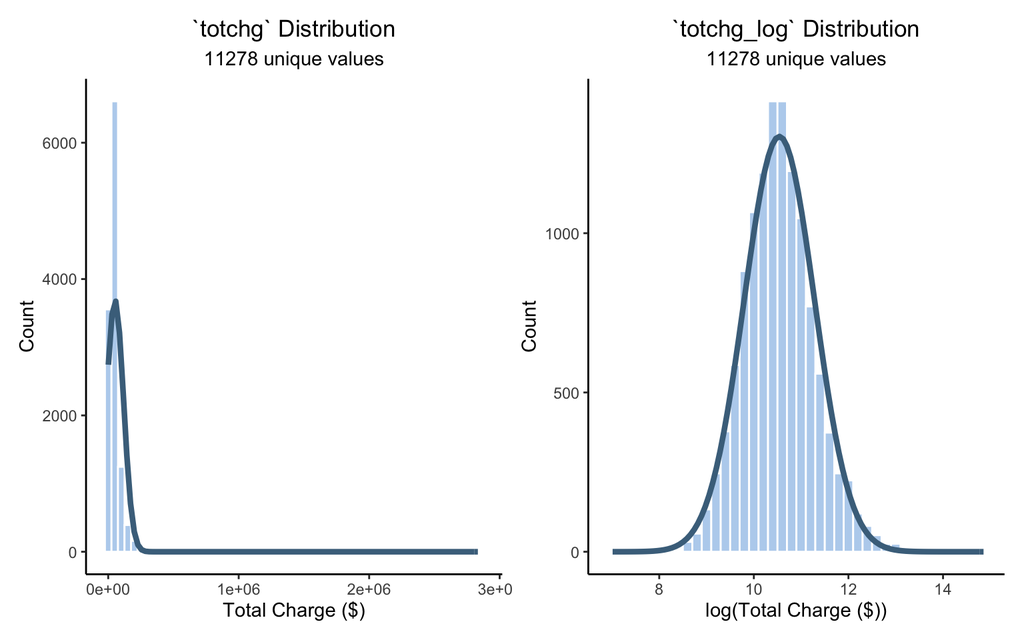

```r
unique_values <- length(unique(regression_data_tidy$totchg)) # for plot subtitle
bin_w1 <- 50000
res1 <- mosaic::fav_stats(regression_data_tidy$totchg)
hist_plot_totchg <-  ggplot(regression_data_tidy, aes(x = totchg)) +
  geom_histogram(binwidth = bin_w1, color = "white", fill = "slategray2") +
  stat_function( # Plot Normal curve
    fun = function(x) dnorm(x, mean = res1$mean,
                            sd = res1$sd) *
      res1$n * bin_w1,
    col = "skyblue4", size = 1.5) +
  labs(title = "`totchg` Distribution",
       subtitle = paste0(unique_values, " unique values"),
       x = "Total Charge ($)", y = "Count") +
  theme_classic() +
  theme(plot.title = element_text(hjust = 0.5),
        plot.subtitle = element_text(hjust = 0.5))


regression_data_tidy$totchg_log <- log(regression_data_tidy$totchg)

unique_values <- length(unique(regression_data_tidy$totchg_log)) # for plot subtitle
bin_w1_log <- 0.2
res1_log <- mosaic::fav_stats(regression_data_tidy$totchg_log)
hist_plot_totchg_log <-  ggplot(regression_data_tidy, aes(x = totchg_log)) +
  geom_histogram(binwidth = bin_w1_log, color = "white", fill = "slategray2") +
  stat_function( # Plot Normal curve
    fun = function(x) dnorm(x, mean = res1_log$mean,
                            sd = res1_log$sd) *
      res1_log$n * bin_w1_log,
    col = "skyblue4", size = 1.5) +
  labs(title = "`totchg_log` Distribution",
       subtitle = paste0(unique_values, " unique values"),
       x = "log(Total Charge ($))", y = "Count") +
  theme_classic() +
  theme(plot.title = element_text(hjust = 0.5),
        plot.subtitle = element_text(hjust = 0.5))


hist_plot_totchg + hist_plot_totchg_log
```

# 4 Tidy Codebook

```r
regression_data_tidy <- regression_data_tidy %>%
  select(-totchg, hosp_region) %>%
  select(key_nis, hosp_nis, discwt, nis_stratum, totchg_log, everything())
```

# 5 Analysis

## 5.1 Split data

```r
set.seed(0)

train_rows <- regression_data_tidy$totchg_log %>%
  createDataPartition(0.8, list = FALSE, times = 1)

regression_data_train <- regression_data_tidy[train_rows, ]
regression_data_test <- regression_data_tidy[-train_rows, ]

any(regression_data_test$key_nis %in% regression_data_train$key_nis) # no overlap
```

```
[1] FALSE
```

```r
saveRDS(regression_data_train, here(data_dir, "regression_data_train.rds"))
saveRDS(regression_data_test, here(data_dir, "regression_data_test.rds"))
```

## 5.2 Develop linear models

First, we’ll need to create a survey design based on our dataset’s strata and weights.

```r
options(survey.lonely.psu="adjust") # assists with survey design when strata have minimal samples

# remove `key_nis` bc it's no longer needed
regression_data_train <- regression_data_train[, !(colnames(regression_data_train) == "key_nis")]

# create survey design for linear regression
design1 <- svydesign(id = ~hosp_nis,
                     strata = ~nis_stratum,
                     weights = ~discwt,
                     nest = TRUE,
                     survey.lonely.psu = "adjust",
                     data = regression_data_train)
```

We’ll save our summary statistics for each of these variables using the `tbl_svysummary` function from the `gtsummary` package.

```r
# remove `key_nis` bc it's no longer needed
regression_data_tidy <- regression_data_tidy[, !(colnames(regression_data_tidy) == "key_nis")]

# create survey design for summary statistics of complete dataset

design_all <- svydesign(id = ~hosp_nis,
                     strata = ~nis_stratum,
                     weights = ~discwt,
                     nest = TRUE,
                     survey.lonely.psu = "adjust",
                     data = regression_data_tidy)

summary_table1 <- tbl_svysummary(design_all,
                                 statistic = list(all_continuous() ~ "{mean} (sd = {sd})", all_categorical() ~ "{n} ({p}%)"))

summary_table1
```

| **Characteristic** | **N = 60,745**<sup>1</sup> |
| --- | --- |
| totchg_log | 10.54 (sd = 0.74) |
| amonth |  |
| 1 | 5,100 (8.4%) |
| 2 | 4,615 (7.6%) |
| 3 | 4,865 (8.0%) |
| 4 | 4,545 (7.5%) |
| 5 | 5,115 (8.4%) |
| 6 | 4,660 (7.7%) |
| 7 | 5,530 (9.1%) |
| 8 | 5,395 (8.9%) |
| 9 | 5,355 (8.8%) |
| 10 | 5,445 (9.0%) |
| 11 | 4,870 (8.0%) |
| 12 | 5,250 (8.6%) |
| aweekend |  |
| 0 | 49,630 (82%) |
| 1 | 11,115 (18%) |
| elective |  |
| 0 | 33,935 (56%) |
| 1 | 26,810 (44%) |
| hosp_division |  |
| 1 | 2,485 (4.1%) |
| 2 | 8,950 (15%) |
| 3 | 6,610 (11%) |
| 4 | 3,480 (5.7%) |
| 5 | 11,950 (20%) |
| 6 | 3,800 (6.3%) |
| 7 | 9,085 (15%) |
| 8 | 3,575 (5.9%) |
| 9 | 10,810 (18%) |

[output cut: 106 more lines]

<sup>*1*</sup> Mean (sd = SD); n (%)

### 5.2.1 Univariate analysis

Run linear regression with each of our predictor variables as a univariate analysis.

```r
# univariate linear regression with each of our final predictors
lm1 <- svyglm(totchg_log ~ amonth, design = design1)
lm1 <- summary(lm1)
lm2 <- svyglm(totchg_log ~ aweekend, design = design1)
lm2 <- summary(lm2)
lm3 <- svyglm(totchg_log ~ elective, design = design1)
lm3 <- summary(lm3)
lm4 <- svyglm(totchg_log ~ hosp_division, design = design1)
lm4 <- summary(lm4)
lm5 <- svyglm(totchg_log ~ i10_ndx, design = design1)
lm5 <- summary(lm5)
lm6 <- svyglm(totchg_log ~ i10_npr, design = design1)
lm6 <- summary(lm6)
lm7 <- svyglm(totchg_log ~ pclass_orproc, design = design1)
lm7 <- summary(lm7)
lm8 <- svyglm(totchg_log ~ pl_nchs, design = design1)
lm8 <- summary(lm8)
lm9 <- svyglm(totchg_log ~ zipinc_qrtl, design = design1)
lm9 <- summary(lm9)
lm10 <- svyglm(totchg_log ~ cmr_depress, design = design1)
lm10 <- summary(lm10)
lm11 <- svyglm(totchg_log ~ cmr_diab_cx, design = design1)
lm11 <- summary(lm11)
lm12 <- svyglm(totchg_log ~ cmr_diab_uncx, design = design1)
lm12 <- summary(lm12)
lm13 <- svyglm(totchg_log ~ cmr_drug_abuse, design = design1)
lm13 <- summary(lm13)
lm14 <- svyglm(totchg_log ~ cmr_htn_cx, design = design1)
lm14 <- summary(lm14)
lm15 <- svyglm(totchg_log ~ cmr_htn_uncx, design = design1)
lm15 <- summary(lm15)
lm16 <- svyglm(totchg_log ~ cmr_lung_chronic, design = design1)
lm16 <- summary(lm16)
lm17 <- svyglm(totchg_log ~ cmr_obese, design = design1)
lm17 <- summary(lm17)
lm18 <- svyglm(totchg_log ~ cmr_thyroid_hypo, design = design1)
lm18 <- summary(lm18)
lm19 <- svyglm(totchg_log ~ aprdrg_risk_mortality, design = design1)
lm19 <- summary(lm19)
lm20 <- svyglm(totchg_log ~ aprdrg_severity, design = design1)
lm20 <- summary(lm20)
lm21 <- svyglm(totchg_log ~ hosp_bedsize, design = design1)
lm21 <- summary(lm21)
lm22 <- svyglm(totchg_log ~ hosp_locteach, design = design1)
lm22 <- summary(lm22)
lm23 <- svyglm(totchg_log ~ hosp_region, design = design1)
lm23 <- summary(lm23)
lm24 <- svyglm(totchg_log ~ n_disc_u, design = design1)
lm24 <- summary(lm24)
lm25 <- svyglm(totchg_log ~ n_hosp_u, design = design1)
lm25 <- summary(lm25)
lm26 <- svyglm(totchg_log ~ s_disc_u, design = design1)
lm26 <- summary(lm26)
lm27 <- svyglm(totchg_log ~ s_hosp_u, design = design1)
lm27 <- summary(lm27)
lm28 <- svyglm(totchg_log ~ total_disc, design = design1)
lm28 <- summary(lm28)
lm29 <- svyglm(totchg_log ~ ccr_nis, design = design1)
lm29 <- summary(lm29)
lm30 <- svyglm(totchg_log ~ wageindex, design = design1)
lm30 <- summary(lm30)
lm31 <- svyglm(totchg_log ~ age_cat, design = design1)
lm31 <- summary(lm31)
lm32 <- svyglm(totchg_log ~ race_cat, design = design1)
lm32 <- summary(lm32)
lm33 <- svyglm(totchg_log ~ payer_cat, design = design1)
lm33 <- summary(lm33)
lm34 <- svyglm(totchg_log ~ h_contrl_cat, design = design1)
lm34 <- summary(lm34)
lm35 <- svyglm(totchg_log ~ los_cat, design = design1)
lm35 <- summary(lm35)


# combine results
regression_results <- rbind(lm1$coefficients,
      lm2$coefficients,
      lm3$coefficients,
      lm4$coefficients,
      lm5$coefficients,
      lm6$coefficients,
      lm7$coefficients,
      lm8$coefficients,
      lm9$coefficients,
      lm10$coefficients,
      lm11$coefficients,
      lm12$coefficients,
      lm13$coefficients,
      lm14$coefficients,
      lm15$coefficients,
      lm16$coefficients,
      lm17$coefficients,
      lm18$coefficients,
      lm19$coefficients,
      lm20$coefficients,
      lm21$coefficients,
      lm22$coefficients,
      lm23$coefficients,
      lm24$coefficients,
      lm25$coefficients,
      lm26$coefficients,
      lm27$coefficients,
      lm28$coefficients,
      lm29$coefficients,
      lm30$coefficients,
      lm31$coefficients,
      lm32$coefficients,
      lm33$coefficients,
      lm34$coefficients,
      lm35$coefficients)

regr_results_clean <- data.frame(regression_results)
colnames(regr_results_clean) <- c("Estimate", "Std_Error", "t_value", "p_value")

included_regr_results <- regr_results_clean %>%
  filter(p_value < (0.05/35))
```

### 5.2.2 Multivariate analysis

Now, we’ll take only the variables that were significant using a corrected p-value (0.05 / 35) and include them in a multivariate analysis. We’ll calculate an r-squared for our model by producing a null model (intercept only, `model_null`), then divide the dispersion parameter from the test model by the dispersion parameter from the null model and subtract that number from 1.

```r
pred_vars_signif <- c("elective",
                      "hosp_division",
                      "i10_ndx",
                      "i10_npr",
                      "pclass_orproc",
                      "pl_nchs",
                      "zipinc_qrtl",
                      "cmr_diab_cx",
                      "cmr_diab_uncx",
                      "cmr_htn_cx",
                      "cmr_htn_uncx",
                      "cmr_lung_chronic",
                      "cmr_obese",
                      "cmr_thyroid_hypo",
                      "aprdrg_risk_mortality",
                      "aprdrg_severity",
                      "hosp_bedsize",
                      "hosp_locteach",
                      "hosp_region",
                      "n_disc_u",
                      "s_disc_u",
                      "total_disc",
                      "ccr_nis",
                      "wageindex",
                      "age_cat",
                      "race_cat",
                      "h_contrl_cat",
                      "los_cat")
# regression_data_train_g <- regression_data_train %>% select(c("key_nis","hosp_nis","discwt","nis_stratum","totchg_log",
#                                                             pred_vars_signif))

model_null <- svyglm(totchg_log ~ 1, design = design1)

model2 <- svyglm(totchg_log ~ elective+
               hosp_division+
               i10_ndx+
               i10_npr+
               pclass_orproc+
               pl_nchs+
               zipinc_qrtl+
               cmr_diab_cx+
               cmr_diab_uncx+
               cmr_htn_cx+
               cmr_htn_uncx+
               cmr_lung_chronic+
               cmr_obese+
               cmr_thyroid_hypo+
               aprdrg_risk_mortality+
               aprdrg_severity+
               hosp_bedsize+
               hosp_locteach+
               hosp_region+
               n_disc_u+
               s_disc_u+
               total_disc+
               ccr_nis+
               wageindex+
               age_cat+
               race_cat+
               h_contrl_cat+
               los_cat,
             design = design1)

summary(model2)
```

```
Call:
svyglm(formula = totchg_log ~ elective + hosp_division + i10_ndx +
    i10_npr + pclass_orproc + pl_nchs + zipinc_qrtl + cmr_diab_cx +
    cmr_diab_uncx + cmr_htn_cx + cmr_htn_uncx + cmr_lung_chronic +
    cmr_obese + cmr_thyroid_hypo + aprdrg_risk_mortality + aprdrg_severity +
    hosp_bedsize + hosp_locteach + hosp_region + n_disc_u + s_disc_u +
    total_disc + ccr_nis + wageindex + age_cat + race_cat + h_contrl_cat +
    los_cat, design = design1)

Survey design:
svydesign(id = ~hosp_nis, strata = ~nis_stratum, weights = ~discwt,
    nest = TRUE, survey.lonely.psu = "adjust", data = regression_data_train)

Coefficients: (3 not defined because of singularities)
                                 Estimate Std. Error t value Pr(>|t|)
(Intercept)                     1.017e+01  1.119e-01  90.871  < 2e-16 ***
elective1                      -4.252e-02  1.383e-02  -3.076  0.00214 **
hosp_division2                  1.729e-01  5.719e-02   3.023  0.00254 **
hosp_division3                  1.081e-01  5.548e-02   1.948  0.05160 .
hosp_division4                  1.599e-01  5.202e-02   3.074  0.00215 **
hosp_division5                  2.140e-01  5.027e-02   4.257 2.19e-05 ***
hosp_division6                  9.711e-02  6.574e-02   1.477  0.13983
hosp_division7                  1.613e-01  5.137e-02   3.139  0.00172 **
hosp_division8                  2.275e-01  5.040e-02   4.515 6.81e-06 ***
hosp_division9                  2.293e-01  5.150e-02   4.453 9.08e-06 ***
i10_ndx                         1.166e-02  1.388e-03   8.402  < 2e-16 ***
i10_npr                         4.229e-02  2.815e-03  15.022  < 2e-16 ***
pclass_orproc1                  2.910e-01  1.281e-02  22.706  < 2e-16 ***
pl_nchs2                       -2.158e-02  2.093e-02  -1.031  0.30271
pl_nchs3                        1.482e-03  2.390e-02   0.062  0.95057
pl_nchs4                        1.389e-03  2.945e-02   0.047  0.96239
pl_nchs5                       -1.020e-02  3.375e-02  -0.302  0.76266
pl_nchs6                        2.006e-02  3.345e-02   0.600  0.54889
zipinc_qrtl.L                  -1.442e-02  1.283e-02  -1.124  0.26104
zipinc_qrtl.Q                  -1.092e-02  1.023e-02  -1.067  0.28598
zipinc_qrtl.C                   1.449e-03  9.466e-03   0.153  0.87834
cmr_diab_cx1                   -7.407e-02  3.182e-02  -2.328  0.02006 *
cmr_diab_uncx1                  6.905e-03  1.629e-02   0.424  0.67174
cmr_htn_cx1                     7.222e-03  1.663e-02   0.434  0.66415
cmr_htn_uncx1                   5.759e-02  3.661e-02   1.573  0.11588
```

[output cut: 26 more lines]

```
h_contrl_catb_govt              3.762e-02  3.527e-02   1.066  0.28642
h_contrl_catc_pvt_for_prof      2.674e-01  3.415e-02   7.830 8.89e-15 ***
los_cat.L                       1.725e+00  3.649e-02  47.284  < 2e-16 ***
los_cat.Q                       1.483e-01  3.059e-02   4.848 1.37e-06 ***
los_cat.C                       3.676e-02  2.673e-02   1.375  0.16925
los_cat^4                       4.167e-02  2.128e-02   1.958  0.05036 .
los_cat^5                       3.015e-02  1.917e-02   1.573  0.11594
los_cat^6                      -7.670e-03  1.595e-02  -0.481  0.63059
los_cat^7                      -1.555e-02  1.244e-02  -1.250  0.21162
---
Signif. codes:  0 '***' 0.001 '**' 0.01 '*' 0.05 '.' 0.1 ' ' 1

(Dispersion parameter for gaussian family taken to be 0.1664423)

Number of Fisher Scoring iterations: 2
```

```r
model2_disp <- summary(model2)$dispersion[1]
null_disp <- summary(model_null)$dispersion[1]
model2_r2 <- 1 - (model2_disp / null_disp)

model2_r2
```

```
[1] 0.6986776
```

Based on the summary of `model2`, we’re going to build a model using main effects (no interaction terms) of all the predictors that were found to be significant in `model2`. Again, we will calculate the r-squared using the method described in the above code chunk.

```r
model3 <- svyglm(totchg_log ~ elective +
               hosp_division +
               i10_ndx+
               i10_npr+
               pclass_orproc+
               cmr_diab_cx+
               aprdrg_risk_mortality+
               aprdrg_severity+
               hosp_bedsize+
               hosp_locteach+
               ccr_nis+
               wageindex+
               age_cat+
               race_cat+
               h_contrl_cat+
               los_cat,
             design = design1)

summary(model3)
```

```
Call:
svyglm(formula = totchg_log ~ elective + hosp_division + i10_ndx +
    i10_npr + pclass_orproc + cmr_diab_cx + aprdrg_risk_mortality +
    aprdrg_severity + hosp_bedsize + hosp_locteach + ccr_nis +
    wageindex + age_cat + race_cat + h_contrl_cat + los_cat,
    design = design1)

Survey design:
svydesign(id = ~hosp_nis, strata = ~nis_stratum, weights = ~discwt,
    nest = TRUE, survey.lonely.psu = "adjust", data = regression_data_train)

Coefficients:
                                Estimate Std. Error t value Pr(>|t|)
(Intercept)                    10.174244   0.101104 100.632  < 2e-16 ***
elective1                      -0.043491   0.013895  -3.130 0.001779 **
hosp_division2                  0.205446   0.047296   4.344 1.49e-05 ***
hosp_division3                  0.133955   0.046847   2.859 0.004300 **
hosp_division4                  0.170027   0.048520   3.504 0.000471 ***
hosp_division5                  0.255527   0.047494   5.380 8.55e-08 ***
hosp_division6                  0.122316   0.064862   1.886 0.059507 .
hosp_division7                  0.171732   0.048439   3.545 0.000403 ***
hosp_division8                  0.232496   0.047804   4.864 1.27e-06 ***
hosp_division9                  0.245810   0.043272   5.681 1.59e-08 ***
i10_ndx                         0.011330   0.001259   8.999  < 2e-16 ***
i10_npr                         0.042808   0.002812  15.222  < 2e-16 ***
pclass_orproc1                  0.292830   0.013007  22.513  < 2e-16 ***
cmr_diab_cx1                   -0.073662   0.031256  -2.357 0.018559 *
aprdrg_risk_mortality.L         0.298536   0.023544  12.680  < 2e-16 ***
aprdrg_risk_mortality.Q         0.086751   0.016391   5.292 1.37e-07 ***
aprdrg_risk_mortality.C         0.009038   0.012691   0.712 0.476467
aprdrg_severity.L               0.036049   0.018755   1.922 0.054769 .
aprdrg_severity.Q              -0.001418   0.013056  -0.109 0.913518
aprdrg_severity.C              -0.020878   0.007792  -2.680 0.007449 **
hosp_bedsize2                  -0.036457   0.024035  -1.517 0.129495
hosp_bedsize3                  -0.026253   0.023215  -1.131 0.258269
hosp_locteach2                 -0.176700   0.036885  -4.791 1.82e-06 ***
hosp_locteach3                 -0.177271   0.032093  -5.524 3.87e-08 ***
ccr_nis                        -1.914165   0.096840 -19.766  < 2e-16 ***
wageindex                       0.738312   0.062617  11.791  < 2e-16 ***
age_cat.L                       0.198098   0.046186   4.289 1.90e-05 ***
age_cat.Q                       0.047746   0.032809   1.455 0.145790
age_cat.C                       0.026517   0.015063   1.760 0.078531 .
race_catb_black                 0.048730   0.014862   3.279 0.001065 **
race_catc_hispanic              0.043290   0.015800   2.740 0.006216 **
race_catd_asian/pacific island -0.016194   0.019146  -0.846 0.397782
race_cate_native american      -0.051836   0.038885  -1.333 0.182696
race_catf_other                -0.010392   0.027829  -0.373 0.708888
h_contrl_catb_govt             -0.002811   0.027893  -0.101 0.919737
h_contrl_catc_pvt_for_prof      0.229005   0.033934   6.749 2.08e-11 ***
los_cat.L                       1.735756   0.036445  47.626  < 2e-16 ***
los_cat.Q                       0.152482   0.030592   4.984 6.90e-07 ***
los_cat.C                       0.038523   0.026901   1.432 0.152335
los_cat^4                       0.043232   0.021309   2.029 0.042641 *
los_cat^5                       0.032800   0.019214   1.707 0.088005 .
los_cat^6                      -0.004301   0.016139  -0.267 0.789873
los_cat^7                      -0.013886   0.012475  -1.113 0.265842
---
Signif. codes:  0 '***' 0.001 '**' 0.01 '*' 0.05 '.' 0.1 ' ' 1

(Dispersion parameter for gaussian family taken to be 0.1678757)

Number of Fisher Scoring iterations: 2
```

```r
model3_disp <- summary(model3)$dispersion[1]
null_disp <- summary(model_null)$dispersion[1]
model3_r2 <- 1 - (model3_disp / null_disp)

model3_r2
```

```
[1] 0.6960827
```

### 5.2.3 Summary of multivariate models

As expected, we had many variables that were significant in univariate analysis. However, many of these lost their signal once we built a multivariate model. This is expected, as many of the variables likely had collinear effects, and once we accounted for multiple predictors, their significance was lost. Our final model, model3, aims to reduce much of this collinearity and only used variables that were significant in `model2`.

Let’s compare the differences in r-squared between our two models.

Despite removing many predictors, our third model accounts for nearly the same amount of variation in our result. That’s a good sign for using the simpler model going forward.

### 5.2.4 Assess `model3` assumptions in training dataset

Let’s check out how `model3` meets the assumptions of a linear model using a few plots.

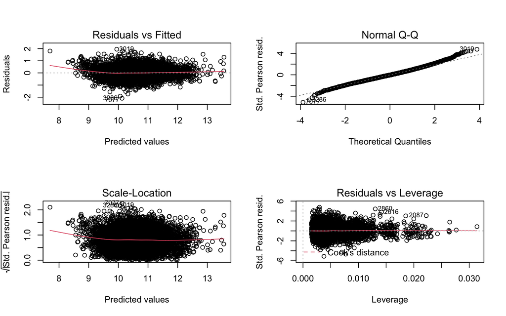

```r
par(mfrow = c(2, 2))

plot(model3)
```

```r
par(mfrom = c(1, 1))
```

And finally, let’s see how our final model performs in the testing dataset. We’ll predict the values for `totchg_log` using the `predict` function and compare the actual vs. predicted values using `geom_point` and `geom_smooth`.

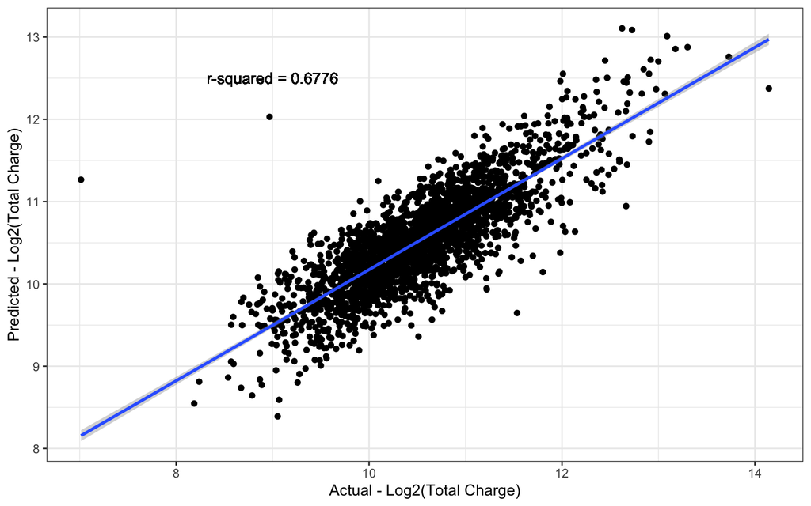

```r
# create predictions of testing data
predicted_totchg_log <- data.frame(predict(model3, newdata = regression_data_test, type = "response"))

# compile predicted and actual values for `totchg_log` using the testing dataset
results_df <- data.frame(Predicted = predicted_totchg_log$response,
                         Actual = regression_data_test$totchg_log)

# function to extract r-squared to add to ggplot below

get_r2 <- function(x , y) {
  m <- lm(y ~ x)
  round(summary(m)$r.squared, 4)
}

results_r2 <- get_r2(results_df$Actual, results_df$Predicted)


g_scatter <- ggplot(results_df, aes(x = Actual, y = Predicted)) +
  geom_point() +
  geom_smooth(method = "lm") +
  geom_text(x = 9, y = 12.5, label = paste("r-squared =", results_r2)) + # from get_r2 above
  labs(x = "Actual - Log2(Total Charge)", y = "Predicted - Log2(Total Charge)") +
  theme_bw()

g_scatter
```